# Statistics Plots

Tom Fletcher

November 2, 2017

We’ll use the Old Faithful data that comes with R. Type just “faithful” and hit enter to see the raw data:

```r
faithful
```

```
    eruptions waiting
1       3.600      79
2       1.800      54
3       3.333      74
4       2.283      62
5       4.533      85
6       2.883      55
7       4.700      88
8       3.600      85
9       1.950      51
10      4.350      85
11      1.833      54
12      3.917      84
13      4.200      78
14      1.750      47
```

[output cut: 258 more lines]

To get information on this data, see the help file by typing this in the R prompt:

```r
?faithful
```

Notice this is a “data frame” in R, which just means a table of data with named columns. To retrieve a single column, use the “$” operator:

```r
faithful$eruptions
```

```
  [1] 3.600 1.800 3.333 2.283 4.533 2.883 4.700 3.600 1.950 4.350 1.833
 [12] 3.917 4.200 1.750 4.700 2.167 1.750 4.800 1.600 4.250 1.800 1.750
 [23] 3.450 3.067 4.533 3.600 1.967 4.083 3.850 4.433 4.300 4.467 3.367
 [34] 4.033 3.833 2.017 1.867 4.833 1.833 4.783 4.350 1.883 4.567 1.750
 [45] 4.533 3.317 3.833 2.100 4.633 2.000 4.800 4.716 1.833 4.833 1.733
 [56] 4.883 3.717 1.667 4.567 4.317 2.233 4.500 1.750 4.800 1.817 4.400
 [67] 4.167 4.700 2.067 4.700 4.033 1.967 4.500 4.000 1.983 5.067 2.017
 [78] 4.567 3.883 3.600 4.133 4.333 4.100 2.633 4.067 4.933 3.950 4.517
 [89] 2.167 4.000 2.200 4.333 1.867 4.817 1.833 4.300 4.667 3.750 1.867
[100] 4.900 2.483 4.367 2.100 4.500 4.050 1.867 4.700 1.783 4.850 3.683
[111] 4.733 2.300 4.900 4.417 1.700 4.633 2.317 4.600 1.817 4.417 2.617
[122] 4.067 4.250 1.967 4.600 3.767 1.917 4.500 2.267 4.650 1.867 4.167
[133] 2.800 4.333 1.833 4.383 1.883 4.933 2.033 3.733 4.233 2.233 4.533
[144] 4.817 4.333 1.983 4.633 2.017 5.100 1.800 5.033 4.000 2.400 4.600
[155] 3.567 4.000 4.500 4.083 1.800 3.967 2.200 4.150 2.000 3.833 3.500
[166] 4.583 2.367 5.000 1.933 4.617 1.917 2.083 4.583 3.333 4.167 4.333
[177] 4.500 2.417 4.000 4.167 1.883 4.583 4.250 3.767 2.033 4.433 4.083
[188] 1.833 4.417 2.183 4.800 1.833 4.800 4.100 3.966 4.233 3.500 4.366
[199] 2.250 4.667 2.100 4.350 4.133 1.867 4.600 1.783 4.367 3.850 1.933
[210] 4.500 2.383 4.700 1.867 3.833 3.417 4.233 2.400 4.800 2.000 4.150
[221] 1.867 4.267 1.750 4.483 4.000 4.117 4.083 4.267 3.917 4.550 4.083
[232] 2.417 4.183 2.217 4.450 1.883 1.850 4.283 3.950 2.333 4.150 2.350
[243] 4.933 2.900 4.583 3.833 2.083 4.367 2.133 4.350 2.200 4.450 3.567
[254] 4.500 4.150 3.817 3.917 4.450 2.000 4.283 4.767 4.533 1.850 4.250
[265] 1.983 2.250 4.750 4.117 2.150 4.417 1.817 4.467
```

Here’s the other column:

```r
faithful$waiting
```

```
  [1] 79 54 74 62 85 55 88 85 51 85 54 84 78 47 83 52 62 84 52 79 51 47 78
 [24] 69 74 83 55 76 78 79 73 77 66 80 74 52 48 80 59 90 80 58 84 58 73 83
 [47] 64 53 82 59 75 90 54 80 54 83 71 64 77 81 59 84 48 82 60 92 78 78 65
 [70] 73 82 56 79 71 62 76 60 78 76 83 75 82 70 65 73 88 76 80 48 86 60 90
 [93] 50 78 63 72 84 75 51 82 62 88 49 83 81 47 84 52 86 81 75 59 89 79 59
[116] 81 50 85 59 87 53 69 77 56 88 81 45 82 55 90 45 83 56 89 46 82 51 86
[139] 53 79 81 60 82 77 76 59 80 49 96 53 77 77 65 81 71 70 81 93 53 89 45
[162] 86 58 78 66 76 63 88 52 93 49 57 77 68 81 81 73 50 85 74 55 77 83 83
[185] 51 78 84 46 83 55 81 57 76 84 77 81 87 77 51 78 60 82 91 53 78 46 77
[208] 84 49 83 71 80 49 75 64 76 53 94 55 76 50 82 54 75 78 79 78 78 70 79
[231] 70 54 86 50 90 54 54 77 79 64 75 47 86 63 85 82 57 82 67 74 54 83 73
[254] 73 88 80 71 83 56 79 78 84 58 83 43 60 75 81 46 90 46 74
```

The “summary” command in R will give you some basic statistics:

```r
summary(faithful)
```

```
   eruptions        waiting
 Min.   :1.600   Min.   :43.0
 1st Qu.:2.163   1st Qu.:58.0
 Median :4.000   Median :76.0
 Mean   :3.488   Mean   :70.9
 3rd Qu.:4.454   3rd Qu.:82.0
 Max.   :5.100   Max.   :96.0
```

The usual sample statistics are also commands:

```r
mean(faithful$eruptions)   # mean
```

```
[1] 3.487783
```

```r
median(faithful$eruptions) # median
```

```
[1] 4
```

```r
var(faithful$eruptions)    # variance
```

```
[1] 1.302728
```

```r
sd(faithful$eruptions)     # standard deviation
```

```
[1] 1.141371
```

As a first visualization, we could look at the histogram.

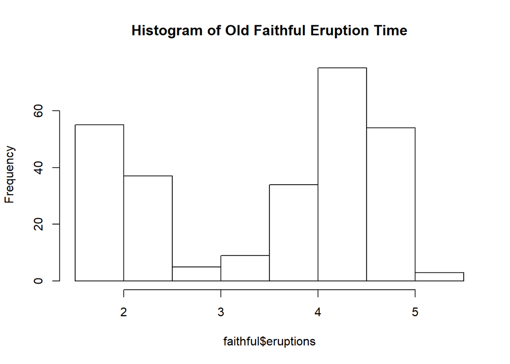

```r
hist(faithful$eruptions, main="Histogram of Old Faithful Eruption Time")
```

You can change the number of bins in the histogram with the `breaks` option.

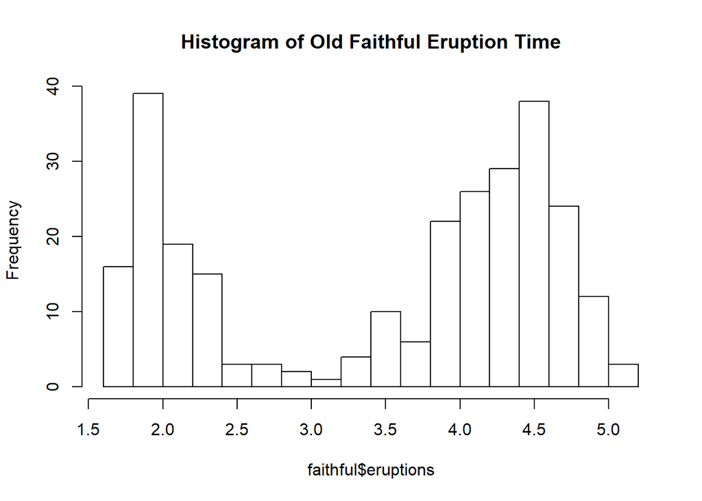

```r
hist(faithful$eruptions, main="Histogram of Old Faithful Eruption Time", breaks=20)
```

The `density()` command in R is another way to visualize the estimated pdf from a data set. Here we will plot it on top of our histogram to compare:

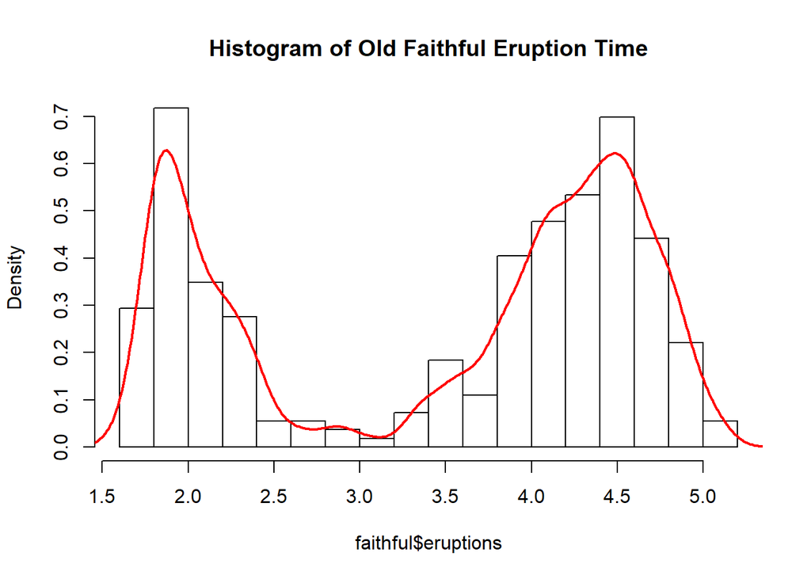

```r
hist(faithful$eruptions, main="Histogram of Old Faithful Eruption Time", breaks=20, freq=FALSE)
lines(density(faithful$eruptions, bw = 0.1), col = 'red', lw = 2)
```

The empirical cdf is plotted using the `ecdf` command.

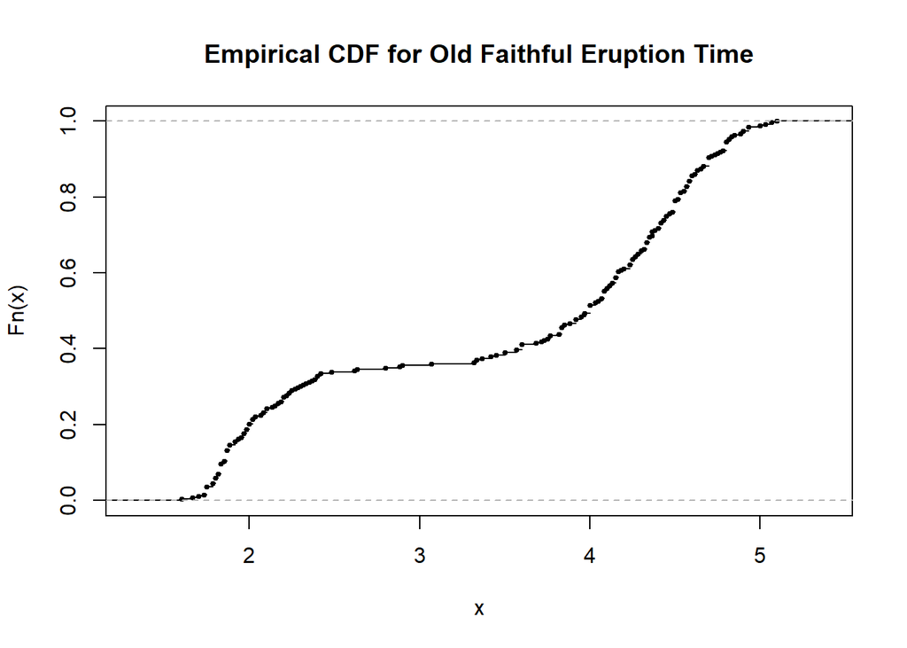

```r
plot(ecdf(faithful$eruptions), cex.points=0.5, main="Empirical CDF for Old Faithful Eruption Time")
```

Here’s how to do box plots:

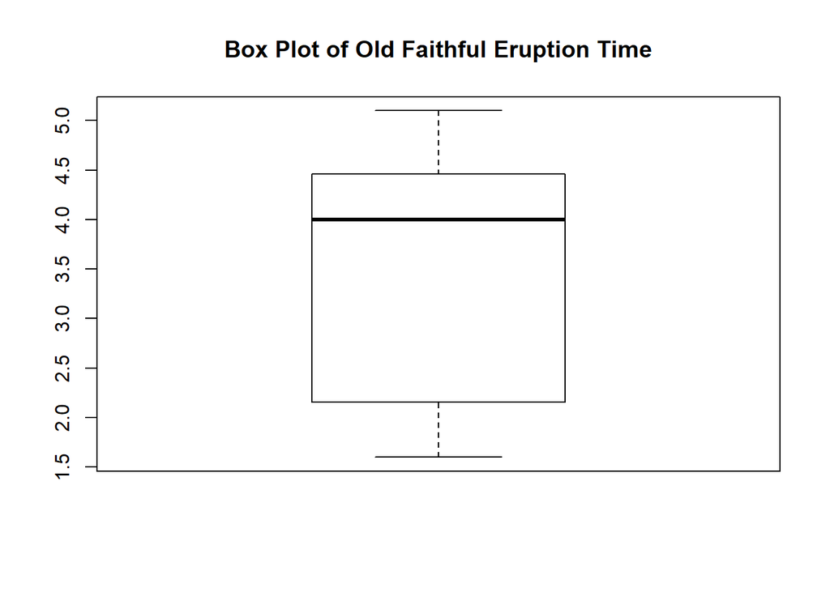

```r
boxplot(faithful$eruptions, main="Box Plot of Old Faithful Eruption Time")
```

We can look at joint statistics such as sample covariance and correlation also.

```r
cov(faithful$waiting, faithful$eruptions)
```

```
[1] 13.97781
```

```r
cor(faithful$waiting, faithful$eruptions)
```

```
[1] 0.9008112
```

Scatter plots are useful for looking at two random variables, $X, Y$, and their relationships.

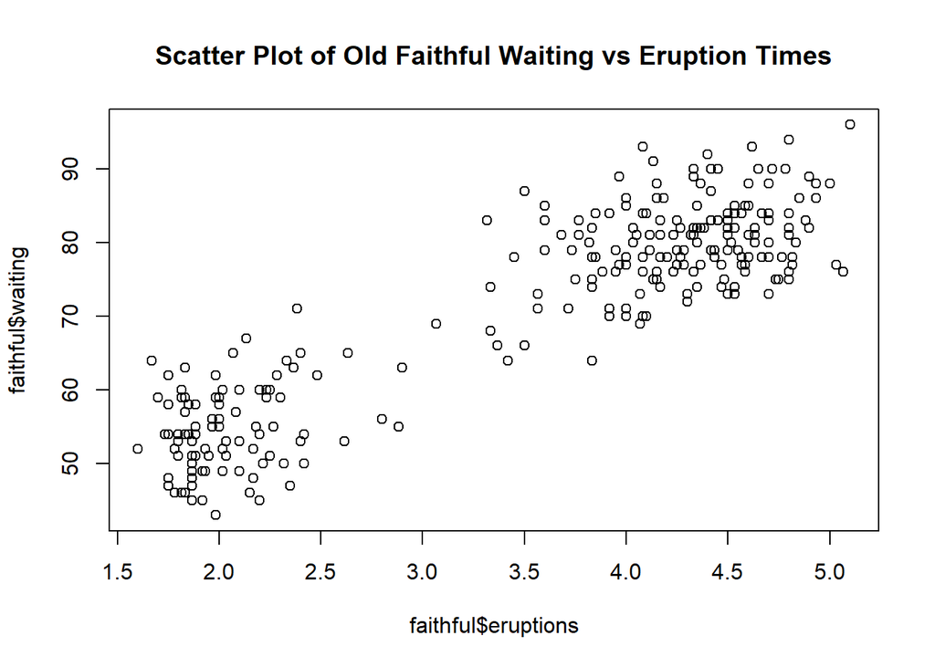

```r
plot(faithful$eruptions, faithful$waiting, main="Scatter Plot of Old Faithful Waiting vs Eruption Times")
```

This example is taken from Wikipedia. It is a box plot of the Michelson-Morley speed of light experiments.

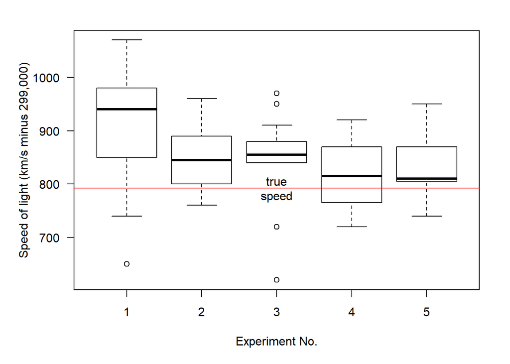

```r
morley$Expt <- factor(morley$Expt)
par(las=1, mar=c(5.1, 5.1, 2.1, 2.1))
boxplot(Speed ~ Expt, morley, xlab = "Experiment No.",
        ylab="Speed of light (km/s minus 299,000)")
abline(h=792.458, col="red")
text(3,792.458,"true\nspeed")
```

Another nice example of a box plot is at the bottom of the help page for boxplot (type `?boxplot` at the R prompt).